# Detector de máscaras utilizando Machine Learning

Neste projeto, iremos utilizar o algoritmo K-Nearest Neighbors (KNN) para o treinamento de um modelo classificador que será capaz de identificar se uma pessoa está ou não portando uma máscara.

Iremos utilizar a biblioteca **OpenCV** de visão computacional para realizar o reconhecimento facial e processamento de imagens.

Também iremos utilizar as bibliotecas **NumPy**, **matplotlib**, **pandas** e **scikit-learn**, para Machine Learning.

```python
# Importanto, carregando as bibliotecas e ignorar avisos

import cv2 as cv
import numpy as np
import pandas as pd
import os
from sklearn.decomposition import PCA
from sklearn.model_selection import train_test_split, GridSearchCV
from sklearn.neighbors import KNeighborsClassifier
from sklearn.metrics import confusion_matrix
import matplotlib.pyplot as plt
import warnings

warnings.filterwarnings("ignore")
```

```python
# Criar função para processar as imagens

def carrega_dataframe():
    dados = {
        "ARQUIVO": [], # Nome do arquivo
        "ROTULO": [], # Verificar se a pessoas está ou não com máscara
        "ALVO": [], # Selecionar o alvo
    }

    # Armazenas os caminhos de onde estão armazenados as imagens em variáveis
    caminho_com_mascara = "imagens/com-mascara"
    caminho_sem_mascara = "imagens/sem-mascara"

    # Listar os arquivos
    com_mascara = os.listdir(caminho_com_mascara)
    sem_mascara = os.listdir(caminho_sem_mascara)

    # Percorrer os arquivos e salvar nas listas vazias

    for arquivo in com_mascara:
        dados["ARQUIVO"].append(f"{caminho_com_mascara}{os.sep}{arquivo}")
        dados["ROTULO"].append(f"Com mascara")
        dados["ALVO"].append(1)

    for arquivo in sem_mascara:
        dados["ARQUIVO"].append(f"{caminho_sem_mascara}{os.sep}{arquivo}")
        dados["ROTULO"].append(f"Sem mascara")
        dados["ALVO"].append(0)

    dataframe = pd.DataFrame(dados)

    return dataframe
```

```python
# Chamando a função

dados = carrega_dataframe()
```

```python
# Salvar o arquivo em .csv

dados.to_csv("dados/imagens-df.csv")
```

```python
# Utilizando o pandas para ler o dataset

dados = pd.read_csv("dados/imagens-df.csv")
```

```python
# Ler as primeiras linhas

dados.head()
```

|  | Unnamed: 0 | ARQUIVO | ROTULO | ALVO |
| --- | --- | --- | --- | --- |
| 0 | 0 | imagens/com-mascara\0.jpg | Com mascara | 1 |
| 1 | 1 | imagens/com-mascara\1.jpg | Com mascara | 1 |
| 2 | 2 | imagens/com-mascara\10.jpg | Com mascara | 1 |
| 3 | 3 | imagens/com-mascara\100.jpg | Com mascara | 1 |
| 4 | 4 | imagens/com-mascara\101.jpg | Com mascara | 1 |

```python
# Função para ler as imagens

def ler_imagens(dados):
  arquivos = dados["ARQUIVO"]
  imagens = list()

# Ler a imagem e converter para escala de cor cinza e utilizar dentro de um vetor
  for arquivo in arquivos:
    img = cv.cvtColor(cv.imread(arquivo), cv.COLOR_BGR2GRAY).flatten()
    imagens.append(img)

# Adicionar nova coluna no dataset
  dados["IMAGEM"] = imagens
```

```python
# Chamar a função

ler_imagens(dados)
```

```python
# Ler as primeiras linhas

dados.head()
```

|  | Unnamed: 0 | ARQUIVO | ROTULO | ALVO | IMAGEM |
| --- | --- | --- | --- | --- | --- |
| 0 | 0 | imagens/com-mascara\0.jpg | Com mascara | 1 | [158, 178, 160, 173, 165, 172, 168, 149, 155, ... |
| 1 | 1 | imagens/com-mascara\1.jpg | Com mascara | 1 | [127, 132, 144, 134, 135, 111, 130, 157, 160, ... |
| 2 | 2 | imagens/com-mascara\10.jpg | Com mascara | 1 | [51, 54, 58, 61, 61, 62, 62, 63, 55, 56, 58, 5... |
| 3 | 3 | imagens/com-mascara\100.jpg | Com mascara | 1 | [50, 57, 46, 56, 60, 54, 65, 56, 57, 45, 33, 2... |
| 4 | 4 | imagens/com-mascara\101.jpg | Com mascara | 1 | [253, 253, 253, 253, 253, 253, 253, 253, 252, ... |

Com nossos dados organizados em um DataFrame, já poderemos dividir em conjunto de treino e teste. Para isso utilizaremos o método **train_test_split()** do scikit-learn.

```python
# Vamos dividir o dataset em conjunto de treino e teste. Para isso utilizaremos o método train_test_split() do scikit-learn.

X = list(dados["IMAGEM"])
y = list(dados["ALVO"])
```

```python
# Dividindo em treino e teste

X_train, X_test, y_train, y_test = train_test_split(X, y, train_size=0.99, random_state=13)
```

Depois de separar em treino e teste o nosso conjunto de dados, iremos refinar as características das imagem. Desse modo, poderemos filtrar as características que são mais importantes para classificar uma face em uma imagem.

Para isso, utilizaremos uma implementação da **Análise de Componentes Principais** (ACP ou PCA). O PCA é um método que tem por finalidade analisar um conjunto de dados e escolher as formas mais representativas para tal. Ou seja, o PCA irá extrair da nossa imagem apenas as características mais notáveis para a classificação.

```python
# Utilizaremos 30 características da imagem e passar para treino

pca = PCA(n_components=30)
pca.fit(X_train)
```

```
PCA(copy=True, iterated_power='auto', n_components=30, random_state=None,
  svd_solver='auto', tol=0.0, whiten=False)
```

```python
# Transformar os conjutos do pca

X_train = pca.transform(X_train)
X_test = pca.transform(X_test)
```

Após extrairmos as características da nossa imagem utilizando o PCA, poderemos realizar treinamento do KNN.

Para isso, utilizaremos a implementação do algoritmo para classificação no scikit-learn, dado por **KNeighborsClassifier()**.

[figure not shown]

Utilizaremos também a estratégia de Grid Search para a escolha dos hiperparâmetros necessários.

```python
# Passando os parametros do modelo KNN

parametros = {
    "n_neighbors": [2, 3, 5, 11, 19, 23, 29],
    "weights": ["uniform", "distance"],
    "metric": ["euclidean", "manhattan", "cosine", "l1", "l2"]
}
```

```python
# Utilizando o GridSearchCV

knn = GridSearchCV(KNeighborsClassifier(), parametros)
```

```python
# Realizando o treinamento

knn.fit(X_train, y_train)
```

```
GridSearchCV(cv=None, error_score='raise',
       estimator=KNeighborsClassifier(algorithm='auto', leaf_size=30, metric='minkowski',
           metric_params=None, n_jobs=1, n_neighbors=5, p=2,
           weights='uniform'),
       fit_params=None, iid=True, n_jobs=1,
       param_grid={'n_neighbors': [2, 3, 5, 11, 19, 23, 29], 'weights': ['uniform', 'distance'], 'metric': ['euclidean', 'manhattan', 'cosine', 'l1', 'l2']},
       pre_dispatch='2*n_jobs', refit=True, return_train_score='warn',
       scoring=None, verbose=0)
```

Com o modelo treinado, poderemos verificar as métricas.

```python
# Nosso modelo tem 80% de precisão

knn.score(X=X_test, y=y_test)
```

```
0.8
```

```python
# Realizar previsão

predicao = knn.predict(X_test)
```

```python
# Gerar matrix de confusão

verdadeiros_positivos, falsos_positivos, falsos_negativos, verdadeiros_negativos = confusion_matrix(y_test, predicao).ravel()
```

```python
verdadeiros_positivos, verdadeiros_negativos
```

```
(7, 1)
```

```python
falsos_positivos, falsos_negativos
```

```
(2, 0)
```

```python
# Instancia para reconhecimento da face ds imagem

classificador = cv.CascadeClassifier(f"{cv.haarcascades}/haarcascade_frontalface_alt2.xml")
```

```python
# Função para processar a imagem

def processar_imagem(pca, classificador, imagem):
  img = cv.imread(imagem)
  imagem_cinza = cv.cvtColor(img, cv.COLOR_BGR2GRAY)
  faces = classificador.detectMultiScale(img)
  vetores = list()
  cont = 0
  fig = plt.figure(figsize=(10,10))
  for x,y,w,h in faces:
    face_cortada = imagem_cinza[y:y+h, x:x+w]
    fig.add_subplot(3, 3, cont+1)
    plt.imshow(cv.cvtColor(face_cortada, cv.COLOR_BGR2RGB))
    cont+=1
    face_cortada = cv.resize(face_cortada, (160,160))
    vetor = face_cortada.flatten()
    vetores.append(vetor)

  plt.show()
  return vetores
```

```python
# Classificando por classe

classes = {
    0: "Sem máscara",
    1: "Com máscara"
}
```

Vamos realizar a previsão do modelo, para as nossas imagens, para prever se estão de máscara ou não.

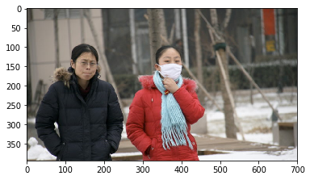

```python
# Carregar e processar a imagem

imagem1 = cv.imread("imagens/avaliar/pessoas-na-rua.jpg")

def mostrar_imagem(imagem1):
  imagem_rgb = cv.cvtColor(imagem1, cv.COLOR_BGR2RGB)
  plt.imshow(imagem_rgb)

mostrar_imagem(imagem1)
```

Aqui nosso modelo acerto, sendo o primeiro rosto sem máscara e o segundo rosto com máscara

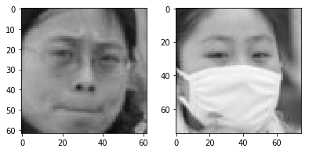

```
Sem máscara - Com máscara
```

```python
vetores = processar_imagem(pca, classificador, "imagens/avaliar/pessoas-na-rua.jpg")
c = knn.predict(pca.transform(vetores))

print(*[classes[e] for e in c], sep=" - ")
```

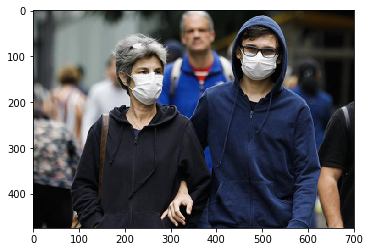

```python
# Segundo teste

imagem2 = cv.imread("imagens/avaliar/pessoas-na-rua-2.jpg")

def mostrar_imagem(imagem2):
  imagem_rgb = cv.cvtColor(imagem2, cv.COLOR_BGR2RGB)
  plt.imshow(imagem_rgb)

mostrar_imagem(imagem2)
```

Aqui nosso modelo acertou novamente, sendo o primeiro rosto sem máscara, segundo rosto com máscara e o terceiro rosto mesmo usando óculos com máscara.

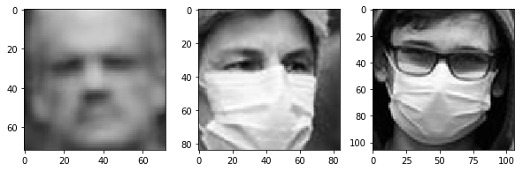

```
Sem máscara - Com máscara - Com máscara
```

```python
vetores = processar_imagem(pca, classificador, "imagens/avaliar/pessoas-na-rua-2.jpg")
c = knn.predict(pca.transform(vetores))

print(*[classes[e] for e in c], sep=" - ")
```